# Modelos de Clasifiacion

En este notebook vamos a trabajar en un caso práctico de clasificación utilizando el dataset de setas [mashroom edible](https://www.kaggle.com/datasets/prishasawhney/mushroomdataset).

Este conjunto de datos incluye información sobre diferentes características de setas, y el objetivo final será determinar si son comestibles o no. A lo largo del ejercicio, exploraremos las características de cada seta y entrenaremos un modelo para predecir su comestibilidad de manera eficiente.

¡Comencemos!

## 1 Importación de librerías y paquetes

```python
# Librerías de análisis y tratamiento de datos
import pandas as pd
# Librerías para visualización de datos
import matplotlib.pyplot as plt
import seaborn as sns
# Librerías para Modelos de ML
from sklearn.linear_model import LogisticRegression
from sklearn.neighbors import KNeighborsClassifier
from sklearn.naive_bayes import GaussianNB
from sklearn.svm import SVC
from sklearn.tree import DecisionTreeClassifier
from sklearn.ensemble import RandomForestClassifier
# Metricas de analisis
from sklearn.metrics import accuracy_score, precision_score, recall_score, roc_curve, auc, confusion_matrix
# Modulos para partición de datos
from sklearn.model_selection import train_test_split
# Otras Librerías y Módulos
import warnings
warnings.filterwarnings("ignore")
```

## 2 Objetivos y Perspectiva general

Vamos a explorar si, a partir de estos datos, podemos predecir si una seta es comestible o no.

A continuación, se muestra la estructura del dataset:

1. Cap diameter (diámetro del sombrero)
2. Cap shape (forma del sombrero):
   - Campana
   - Cónica
   - Convexa
   - Plana
   - Hundida
   - Esférica
   - Otras
3. Gill attachment (Unión de las láminas):
   - Adnato
   - Anexo
   - Fecurrente
   - Libres
   - Sinuate
   - Poros
   - None
4. Gill color (Color de las láminas):
   - Marrón
   - Ante
   - Gris
   - Verde
   - Rosa
   - Lila
   - Rojo
   - Blanco
   - Amarillo
   - Azul
   - Naranja
   - Blanco
5. Stem height (Altura del tallo)
6. Stem width (Ancho del tallo)
7. Stem color (Color del tallo) `none = 12`
8. Season (Estación):
   - `Spring = 0.02737213`
   - `Summer = 0.88845029`
   - `Autumn = 0.94319455`
   - `Winter = 1.80427271`
9. Class (Clase):
   - Comestible
   - Venenosa

[figure not shown]

Por lo tanto, el objetivo de este ejercicio es construir un modelo robusto aplicando métodos de clasificación que nos ayude a predecir si nuevas setas son venenosas o no en base a los datos disponbiles etiquetados.

## 3 Lectura y visualización de datos

```python
# Importación del dataset
df = pd.read_csv(r".\datasets\mushroom\mushroom_cleaned.csv")
df.head()
```

|  | cap-diameter | cap-shape | gill-attachment | gill-color | stem-height | stem-width | stem-color | season | class |
| --- | --- | --- | --- | --- | --- | --- | --- | --- | --- |
| 0 | 1372 | 2 | 2 | 10 | 3.807467 | 1545 | 11 | 1.804273 | 1 |
| 1 | 1461 | 2 | 2 | 10 | 3.807467 | 1557 | 11 | 1.804273 | 1 |
| 2 | 1371 | 2 | 2 | 10 | 3.612496 | 1566 | 11 | 1.804273 | 1 |
| 3 | 1261 | 6 | 2 | 10 | 3.787572 | 1566 | 11 | 1.804273 | 1 |
| 4 | 1305 | 6 | 2 | 10 | 3.711971 | 1464 | 11 | 0.943195 | 1 |

```python
# Eliminación de duplicados
df = df.drop_duplicates()
```

```python
# Visualización de información clave de cada campo
df.info()
```

```
<class 'pandas.core.frame.DataFrame'>
Index: 53732 entries, 0 to 54034
Data columns (total 9 columns):
 #   Column           Non-Null Count  Dtype
---  ------           --------------  -----
 0   cap-diameter     53732 non-null  int64
 1   cap-shape        53732 non-null  int64
 2   gill-attachment  53732 non-null  int64
 3   gill-color       53732 non-null  int64
 4   stem-height      53732 non-null  float64
 5   stem-width       53732 non-null  int64
 6   stem-color       53732 non-null  int64
 7   season           53732 non-null  float64
 8   class            53732 non-null  int64
dtypes: float64(2), int64(7)
memory usage: 4.1 MB
```

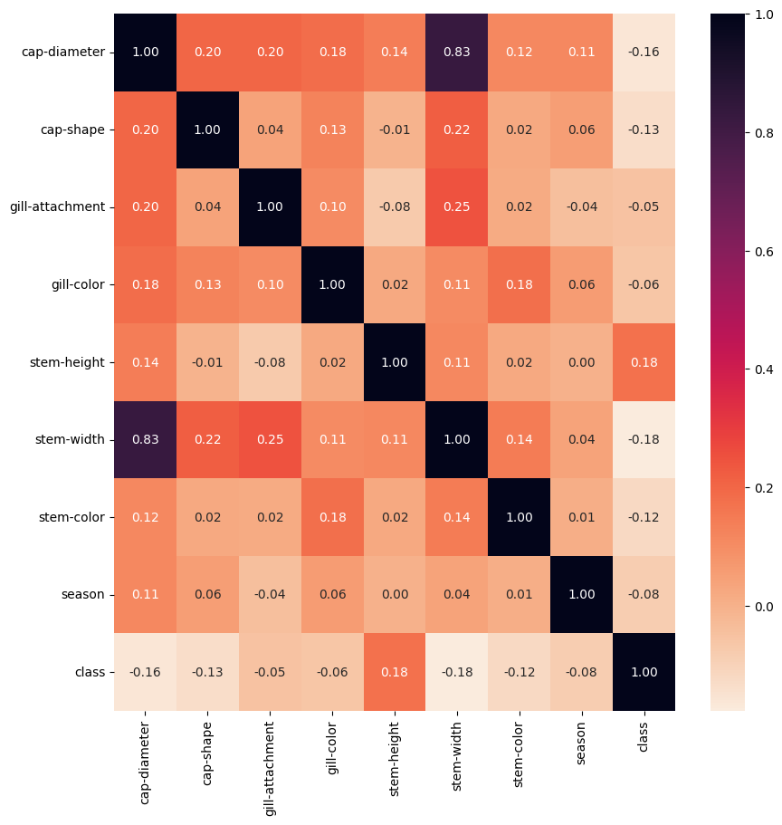

```python
# Graficación de matriz de correlación de los campos del dataset
plt.subplots(figsize=(10,10))
sns.heatmap(df.corr(), cmap = "rocket_r", annot=True, fmt=".2f")
plt.show()
```

## 3 Exploración de los datos (EDA)

En el siguiente gráfico, podemos ver la distribución de los datos que tenemos. Esto nos puede ayudar a saber si la información esta sesgada o si hay valores que predominen sobre el resto.

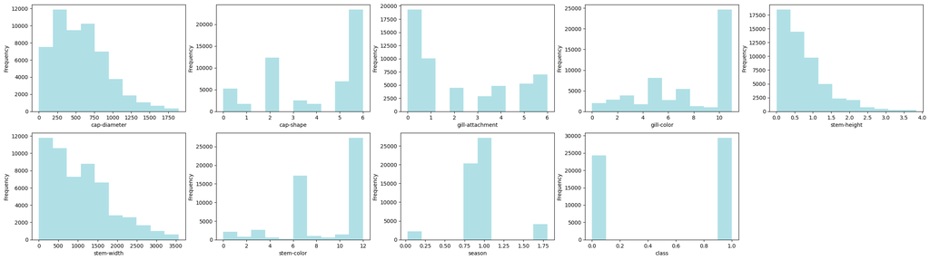

```python
#Visualización de la distribución de los datos
fig = plt.figure(figsize=(30, 8))

for i, column in enumerate(df):
    sub = fig.add_subplot(2, 5, i + 1)
    sub.set_xlabel(column)
    df[column].plot(kind='hist', color='powderblue')
    sub.set_xlabel(column)
```

En los siguientes gráficos tenemos la distribución separada por clases. Así podemos ver si hay algun atributo que predomine para cada clase sobre los otros.

Como diferencias considerables podemos ver que en *grill attechment* (unión de las láminas), hay cierta diferenciación entre si es comestible o no. En *grill color* (color de las láminas) y *stem color* (color del tallo), se puede observar que hay colores que si pueden ser indicatibos de la clase *target*.

También podemos ver que las setas comestibles tienden a tener el sombrero más grande y el tallo más corto y ancho.

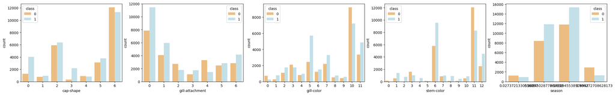

```python
# Análisis de atributos discrtos
category = ['cap-shape', 'gill-attachment', 'gill-color', 'stem-color', 'season']
fig = plt.figure(figsize=(30, 4))


for i, column in enumerate(category):
    sub = fig.add_subplot(1, 5, i + 1)
    chart = sns.countplot(data=df, x=column, hue='class', palette='RdYlBu')
```

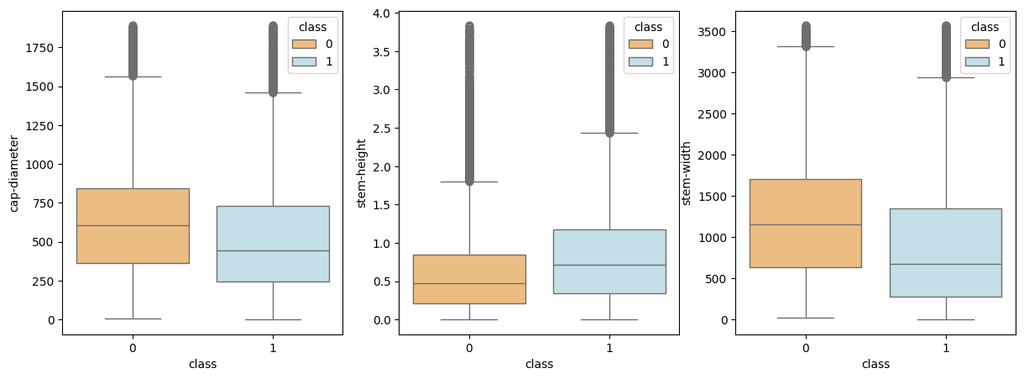

```python
# Análisis de atributos continuos
continuous = ['cap-diameter', 'stem-height', 'stem-width']
fig = plt.figure(figsize=(25, 5))

for i, column in enumerate(continuous):
    sub = fig.add_subplot(1, 5, i + 1)
    sns.boxplot(data=df, x='class', y=column, hue='class', palette='RdYlBu')
```

## 4 Entranamiento y Comparativa de modelos

En este apartado entrenaremos y compararemos los modelos mencionados en la explicación teórica de los modelos de clasificación (Regresión logística, KNN, SVM, *Naive Bayes*, árbol de decisión y *random forest*).

El objetivo es identificar cuál de todos ellos se adapta mejor a esta problemática de clasificación dividiendo los datos en *test* y *train* para ver como se comportan cada uno.

```python
# Extracción de las variables independientes (X) y la variable dependiente (y)
X = df.drop(['class'], axis=1)
y = df["class"]

# División del dataset en training y test
X_train, X_test, y_train, y_test = train_test_split(X, y, test_size=0.33, random_state=42)
```

```python
# Listado de modelos a entrenar
models = [LogisticRegression(), KNeighborsClassifier(n_neighbors=10, weights='uniform', algorithm='auto'), SVC(), GaussianNB(), DecisionTreeClassifier(), RandomForestClassifier()]
models_list = ["Logistic Regression", "KNN", "SVM", "Naive Bayes", "Decision Tree", "Random Forest"]
accuracies = []
precisions = []
recalls = []
aucs = []
confusion_matrixs = []
rocs = []
# Entrenamiento de modelos y obteción de valores de predicción
for model in models:
    model.fit(X_train, y_train)
    y_pred = model.predict(X_test)
    accuracies.append(accuracy_score(y_test, y_pred))
    precisions.append(precision_score(y_test, y_pred))
    recalls.append(recall_score(y_test, y_pred))
    fpr, tpr, _ = roc_curve(y_test, y_pred)
    rocs.append((fpr, tpr))
    aucs.append(round(auc(fpr, tpr), 2))
    confusion_matrixs.append(confusion_matrix(y_test, y_pred))
```

## 5 Evaluación de Modelos

Para evaluar el rendimento de cada modelo usaremos las métricas más típicas: *accuracy*, *precision*, *recall*, curva roc y la matriz de confusión.

```
Logistic Regression
accuracy: 0.6289758628468306	 precision: 0.6519385091366141	 recall: 0.6935815675786875	 auc: 0.62
KNN
accuracy: 0.6987931423415294	 precision: 0.7545613015688554	 recall: 0.6678666940958651	 auc: 0.7
SVM
accuracy: 0.641551996390706	 precision: 0.6666336633663367	 recall: 0.6925529726393747	 auc: 0.64
Naive Bayes
accuracy: 0.6223212271599369	 precision: 0.6392853853946036	 recall: 0.7140506068710142	 auc: 0.61
Decision Tree
accuracy: 0.9759756372659598	 precision: 0.9771094231164033	 recall: 0.9791195227319481	 auc: 0.98
Random Forest
accuracy: 0.9893413038574329	 precision: 0.9901285347043702	 recall: 0.9904340670643901	 auc: 0.99
```

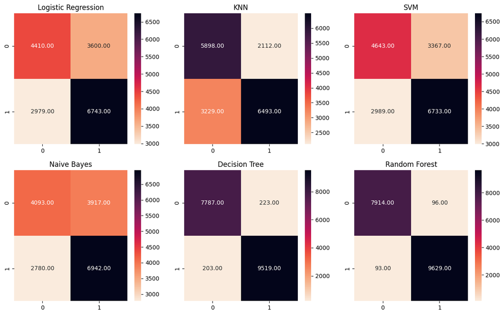

```python
# Lista de modelos a evaluar
models_list = ["Logistic Regression", "KNN", "SVM", "Naive Bayes", "Decision Tree", "Random Forest"]

# Aplicación de la matriz de confusión para analalizar los resultados obtenidos
fig = plt.figure(figsize=(15, 9))

for i, model_name in enumerate(models_list):
    print(model_name)
    print(f"accuracy: {accuracies[i]}\t precision: {precisions[i]}\t recall: {recalls[i]}\t auc: {aucs[i]}")
    sub = fig.add_subplot(2, 3, i + 1).set_title(model_name)
    sns.heatmap(confusion_matrixs[i], cmap = "rocket_r", annot=True, fmt=".2f")
```

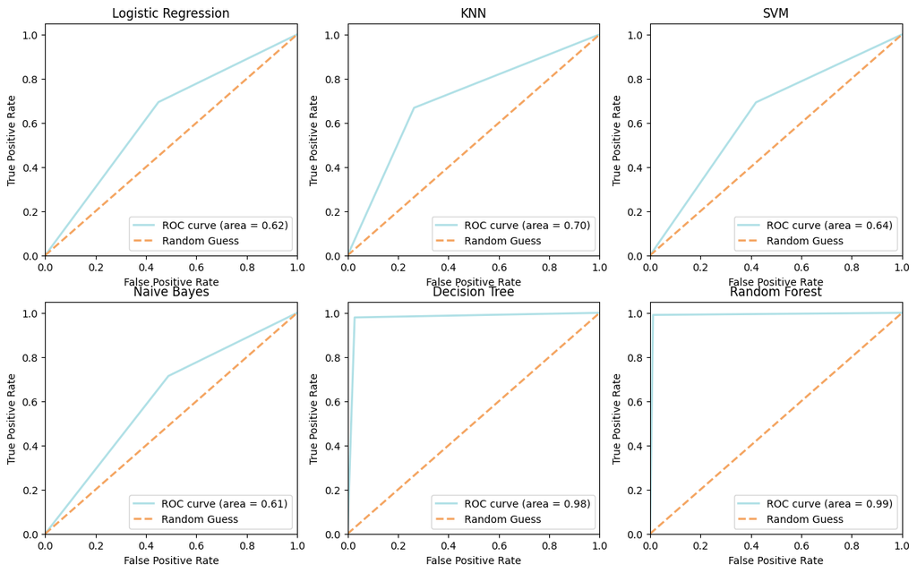

```python
#Aplicación de la curva de ROC para analalizar los resultados
fig = plt.figure(figsize=(15, 9))

for i, model_name in enumerate(models_list):
    sub = fig.add_subplot(2, 3, i + 1)
    sub.plot(rocs[i][0], rocs[i][1], color='powderblue', lw=2, label='ROC curve (area = %0.2f)' % aucs[i])
    sub.plot([0, 1], [0, 1], color='sandybrown', lw=2, linestyle='--', label='Random Guess')
    sub.set_xlim([0.0, 1.0])
    sub.set_ylim([0.0, 1.05])
    sub.set_xlabel('False Positive Rate')
    sub.set_ylabel('True Positive Rate')
    sub.set_title(model_name)
    sub.legend(loc='lower right')
```

Tras la obtención de los resultados finales, podemos ver que la regresión logística, SVM y *Naive Bayes* tienen rendimientos muy similares y significativamente bajos, pues al final solo están acertando un poco más de la mitad de las veces cuando dan la clasificación, párcticamente es como si lanzaramos una moneda al aire. El KNN tiene un pequeño mejor resultado en cuanto al *accuracy* y a la *precision*, pero no llega a ser competente. Si miarmos las matrices de confusión, vemos que el KNN clasifica ligeramente mejor cuando son comestibles que los otros tres modelos.

Por el otro lado el árbol de decisón y el *random forest* tienen un rendimiento muy cercano al 100%, siendo ligeramente mejor el *random forest*. De hecho, si observamos la matriz de confusión podemos ver que el *random forest* falla la mitad de las veces que el árbol de decisión dando un resultado muy apurado.

Estos resultados indican que para esta estructura de datos lo mejor es algún tipo de árbol. Esto no desmerece al resto de modelos, simplemente que para este problema no se adhieren adecuadamente como si lo pueden hacer en otros.

#### ¡Muchas gracias por leer nuestro artículo!